# DAKOTA COUNTY JAIL

# ICE Detention Facility Statistical Report

*Data as of July 09, 2026 - Using Interval ADP Calculations*

[*Back to Detention Reports*](https://detentionreports.com/)

Leer en español

## Key Statistics

| Facility Metric | Value |
| --- | --- |
| Address | 1601 Broadway, Dakota City, NE 68731 |
| Total Average Daily Population (Interval ADP) | 45 |
| Average Length of Stay | 23 days |
| Male Population | 39 |
| Female Population | 6 |
| Criminal Population | 23 |
| Non-Criminal Population | 22 |
| Facility Type | USMS IGA |
| Area of Responsibility | SPM |
| Guaranteed Minimum | Not Available |
| Owner | Dakota County |
| Operator | Dakota County Sheriff's Office |
| Institutional Type | Local |

## Facility Location

[interactive chart not shown]

[🗺️ View Interactive Map](https://maps.google.com/maps?q=42.416071,-96.419792) [🧭 Get Directions](https://www.google.com/maps/dir//42.416071,-96.419792)

## Interval Average Daily Population (Interval ADP)

This is a backward moving average calculation of facility populations based on ICE data. For more information, see the background paper [here](https://relevant-research.com/work).

[figure not shown]

## Average Length of Stay and Interval ADP Scatter Plot

[figure not shown]

## Interval ADP by Detainee Classification

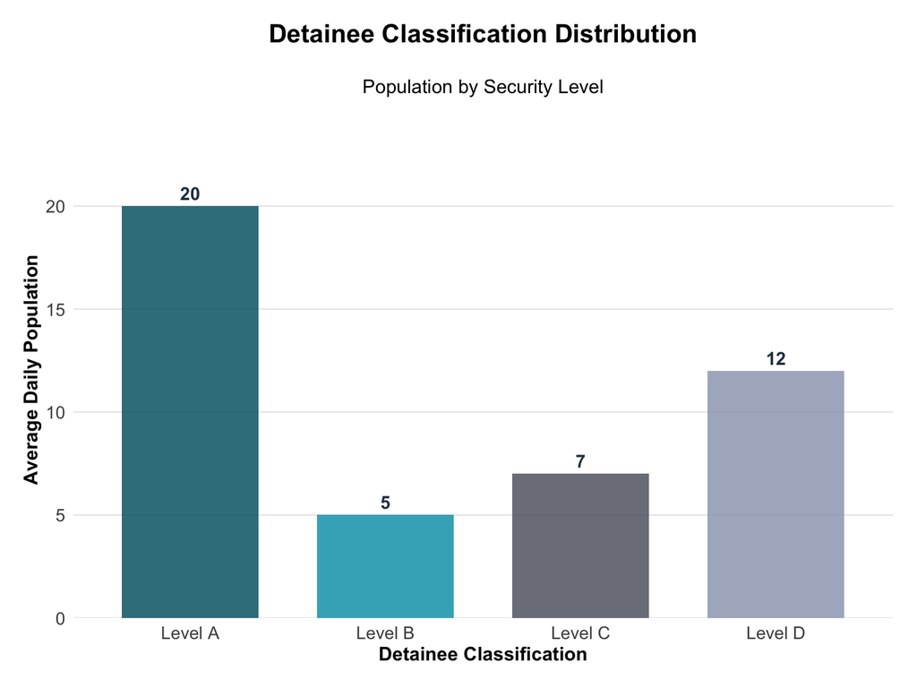

ICE defines these classifications as follows:

*Upon admission and periodically thereafter, detainees are categorized into a security level based on a variety of public safety factors, and are housed accordingly.*

*Factors include prior convictions, threat risk, disciplinary record, special vulnerabilities, and special management concerns.*

*Detainees are categorized into one of four classes of security risk:*

- *A/low*
- *B/medium low*
- *C/medium high*
- *D/high*

*Due to rounding, summing the Security Classification totals may not equal the facility’s aggregate Interval ADP. Please refer to the [notes](https://detentionreports.com/notes.html) page for more information.

## Interval ADP by Gender and Criminal Status

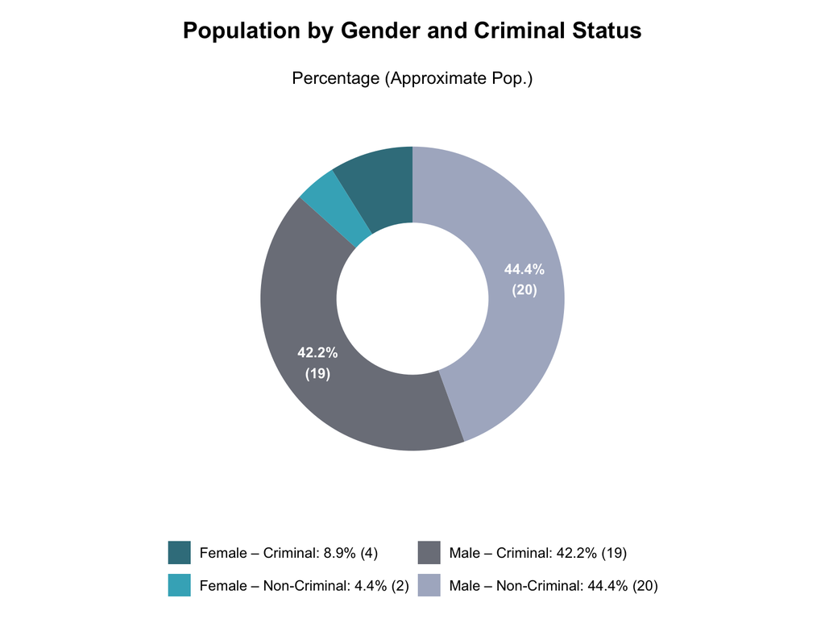

ICE defines criminality as follows:

- *Convicted Criminal:*
  - *Immigration Violators with a criminal conviction entered into ICE systems of record at the time of ICE custody.*
- *Pending Criminal Charges:*
  - *Immigration Violators with pending criminal charges entered into ICE system of record at the time of ICE custody.*
- *Other Immigration Violators:*
  - *Immigration Violators without any known or a criminal conviction, or pending charges entered into ICE system of record at the time of ICE custody.*

ICE reduces these three categories into two for their facility reporting: “Criminal” and “Non-Criminal”. ICE does not clearly explain its method for disaggregating criminality in ICE Detention Statistics documentation. Comparing percentages across other ICE reporting metrics suggests that ICE includes people with Pending Criminal Charges as part of the “Non-Criminal” category for reporting purposes.

*Due to rounding, summing the Gender and Criminal Status totals may not equal the facility’s aggregate Interval ADP. Please refer to the [notes](https://detentionreports.com/notes.html) page for more information.

## Mandatory Detention

Certain sections of the Immigration and Nationality Act require the detention of certain individuals under what is called “Mandatory Detention.” Generally, individuals in mandatory detention cannot be bonded out. ICE reports the mandatory detainee population for each facility as a fiscal year average daily population. See [notes](https://detentionreports.com/notes.html) for further details.

[figure not shown]

## Contract Information

*No contracts found for this facility.*

[*Back to Detention Reports*](https://detentionreports.com/)

*Report generated on July 21, 2026 using ICE Integrated Decision Support (IIDS) interval ADP data from July 09, 2026*

Developed by [Relevant Research](https://relevant-research.com/). For information about the methodology behind Interval ADP, [click here](https://relevant-research.com/work).